# Datenanalyse mit R / Data analysis with R - Exam

by Damian Wollny, Julia Micheel, Aram Safrastyan

2023-02-09

## General Information

The following exam is build on the so-called `iris` dataset, which is pre-installed in every R environment. You should be able to answer all questions without knowing the data. But in order to give you an idea what the data looks like, here are the first 5 rows:

```
##   Sepal.Length Sepal.Width Petal.Length Petal.Width Species
## 1          5.1         3.5          1.4         0.2  setosa
## 2          4.9         3.0          1.4         0.2  setosa
## 3          4.7         3.2          1.3         0.2  setosa
## 4          4.6         3.1          1.5         0.2  setosa
## 5          5.0         3.6          1.4         0.2  setosa
```

… and here is the structure of the data:

```
## 'data.frame':    150 obs. of  5 variables:
##  $ Sepal.Length: num  5.1 4.9 4.7 4.6 5 5.4 4.6 5 4.4 4.9 ...
##  $ Sepal.Width : num  3.5 3 3.2 3.1 3.6 3.9 3.4 3.4 2.9 3.1 ...
##  $ Petal.Length: num  1.4 1.4 1.3 1.5 1.4 1.7 1.4 1.5 1.4 1.5 ...
##  $ Petal.Width : num  0.2 0.2 0.2 0.2 0.2 0.4 0.3 0.2 0.2 0.1 ...
##  $ Species     : Factor w/ 3 levels "setosa","versicolor",..: 1 1 1 1 1 1 1 1 1 1 ...
```

## Question 1: Selecting columns

How was the data modified to get the resulting dataframe (compare before vs. after)

**Before:**

```
##   Sepal.Length Sepal.Width Petal.Length Petal.Width Species
## 1          5.1         3.5          1.4         0.2  setosa
## 2          4.9         3.0          1.4         0.2  setosa
## 3          4.7         3.2          1.3         0.2  setosa
## 4          4.6         3.1          1.5         0.2  setosa
## 5          5.0         3.6          1.4         0.2  setosa
```

**After:**

```
##   Sepal.Length Sepal.Width Petal.Length Petal.Width
## 1          5.1         3.5          1.4         0.2
## 2          4.9         3.0          1.4         0.2
## 3          4.7         3.2          1.3         0.2
## 4          4.6         3.1          1.5         0.2
## 5          5.0         3.6          1.4         0.2
```

**Which answer is not correct:**

A.) `select(-Species)`  
B.) `select(Sepal.Length, Sepal.Width, Petal.Length, Petal.Width)`  
C.) `select(c(Sepal.Length,Sepal.Width,Petal.Length,Petal.Width))`  
D.) `select(-c(Sepal.Length,Sepal.Width,Petal.Length,Petal.Width))`

## Question 2: Filtering dataframes

How was the data filtered to get the resulting dataframe (compare before vs. after)

**Before:**

```
##   Petal.Width    Species
## 1         0.1     setosa
## 2         0.2     setosa
## 3         1.6 versicolor
## 4         1.2 versicolor
## 5         1.5  virginica
## 6         2.2  virginica
```

**After:**

```
##   Petal.Width    Species
## 1         1.6 versicolor
## 2         1.2 versicolor
## 3         1.5  virginica
```

**Which answer is correct:**

A.) `filter(Species != setosa & Petal.Width < 2)`  
B.) `filter(Species != "setosa" & Petal.Width < 2)`  
C.) `filter(Species != setosa | Petal.Width < 2)`  
D.) `filter(Species != "setosa" | Petal.Width < 2)`

## Question 3: Generating new columns

You want to generate a new column and use it for calculations as described in the code below:

```r
iris %>% # line1
  mutate(new_column == 2) %>%  # line2
  mutate(Petal.Length + new_column) # line3
```

**Is the code correct?**

A.) `code is correct`  
B.) `line 1 contains an error`  
C.) `line 2 contains an error`  
D.) `line 3 contains an error`

## Question 4: Piping - *Part1*

What change to the code will resolve the following error?

```
## Error in iris %>% select(Petal.Length): could not find function "%>%"
```

**Which answer is correct:**

A.) library *ggplot* needs to be loaded first (`library(ggplot2)`)  
B.) substitute `%>%` with `%in%`  
C.) *Petal.Length* needs to be in quotation marks (`select("Petal.Length")`)  
D.) library *dplyr* needs to be loaded first (`library(dplyr)`)

## Question 5: Piping - *Part2*

Which sequence of the following commands

w.) `rename(petal_l = Petal.Length)`  
x.) `mutate(petal_sum = petal_l + Petal.Width)`  
y.) `select(Petal.Length, Petal.Width)`  
z.) `filter(Petal.Length > 6 & Petal.Width < 2)`

will generate this dataframe

```
##   petal_l Petal.Width petal_sum
## 1     6.3         1.8       8.1
## 2     6.1         1.9       8.0
```

**Which answer is correct:**

A.) iris %>% w %>% y %>% z %>% x  
B.) iris %>% y %>% w %>% z %>% x  
C.) iris %>% y %>% z %>% w %>% x  
D.) iris %>% z %>% y %>% x %>% w

## Question 6: Plotting data - *Part1*

You want the plot you can see below using the following code:

**Code:**

```r
iris %>% # line 1
  ggplot(aes(x = Species, y = Sepal.Length, color = Species)) %>%  # line 2
  geom_boxplot() # line 3
```

**Plot:**

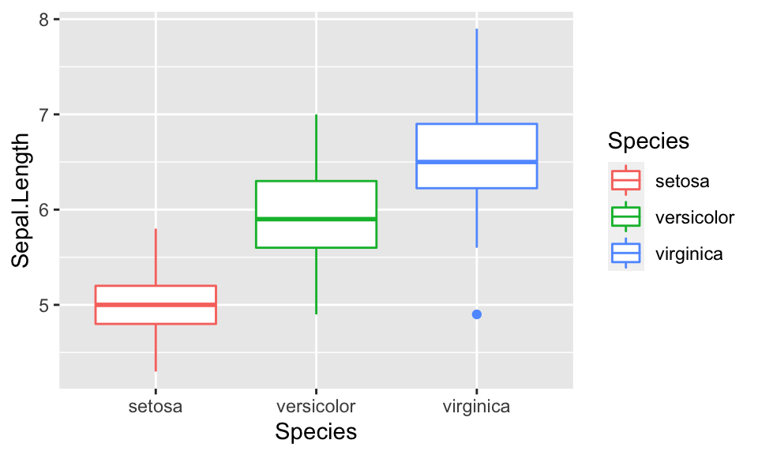

**Is the code correct?**

A.) `code is correct`  
B.) `line 1 contains an error`  
C.) `line 2 contains an error`  
D.) `line 3 contains an error`

## Question 7: Plotting data - *Part2*

Which code will give you the plot you can see below:

**Plot:**

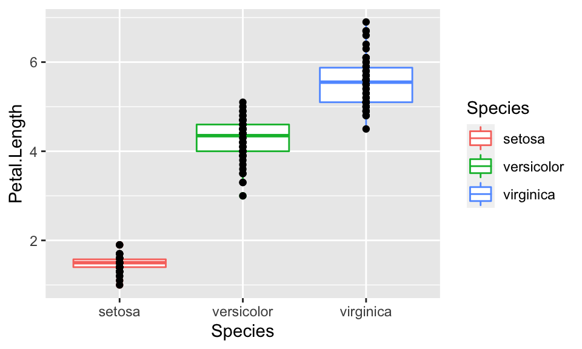

**Which answer is correct:**

A.) `ggplot(data = iris, mapping = aes(x = Species, y = Petal.Length)) + geom_boxplot(aes(color = Species)) + geom_point()`  
B.) `ggplot(data = iris, mapping = aes(x = Species, y = Petal.Length, color = Species)) + geom_boxplot() + geom_point()`  
C.) `ggplot(data = iris, mapping = aes(x = Species, y = Petal.Length)) + geom_boxplot() + geom_point(aes(color = Species))`  
D.) `ggplot(data = iris, mapping = aes(x = Species, y = Petal.Length), color = Species) + geom_boxplot() + geom_point()`

## Question 8: Summarize data

Which code will give you the table you can see below:

**Plot:**

```
## # A tibble: 3 × 3
##   Species    count ave_petal.width
##   <fct>      <int>           <dbl>
## 1 setosa        50           0.246
## 2 versicolor    50           1.33
## 3 virginica     50           2.03
```

**Which answer is correct:**

A.) `group_by(Petal.Width) %>% summarise(Species, count = n())`  
B.) `group_by(Species) %>% summarise(count = n(), ave_petal.width = mean(Petal.Width))`  
C.) `group_by(Species, Petal.Width) %>% summarise(ave_petal.width = mean(), count = n())`  
D.) `group_by(Species, mean(Petal.Width)) %>% summarise(count = n())`

## Question 9: Regular expression - *Part1*

Which regular expression will **not** filter the table correctly (compare before vs. after)

**Before:**

```
##      Species  n
## 1     setosa 50
## 2 versicolor 50
## 3  virginica 50
```

**After:**

```
##      Species  n
## 1 versicolor 50
## 2  virginica 50
```

**Which code will not give the desired outcome:**

A.) `filter(str_detect(Species, "v.r"))`  
B.) `filter(str_detect(Species, "^v."))`  
C.) `filter(str_detect(Species, "v+r"))`  
D.) `filter(str_detect(Species, "v[e|i]r"))`

## Question 10: Regular expression - *Part2*

Which regular expression will filter the table correctly (compare before vs. after)

**Before:**

```
##      Species  n
## 1     setosa 50
## 2 versicolor 50
## 3  virginica 50
```

**After:**

```
##      Species  n
## 1     setosa 50
## 2 versicolor 50
```

**Which answer is correct:**

A.) `filter(str_detect(Species, "o{2}"))`  
B.) `filter(str_detect(Species, "o?"))`  
C.) `filter(str_detect(Species, "o*"))`  
D.) `filter(str_detect(Species, "o+"))`

## Question 11: Tidy data

Which code, will get you the data in the desired format (compare before vs. after)

**Before:**

```
##   Sepal.Length Sepal.Width Petal.Length Petal.Width Species
## 1          5.1         3.5          1.4         0.2  setosa
```

**After:**

```
##   Species   Attributes Value
## 1  setosa Sepal.Length   5.1
## 2  setosa  Sepal.Width   3.5
## 3  setosa Petal.Length   1.4
## 4  setosa  Petal.Width   0.2
```

**Which answer is correct:**

A.) `pivot_longer(cols = !Species, names_to = "Value", values_to = "Attributes")`  
B.) `pivot_longer(cols = !Species, names_to = "Attributes", values_to = "Value")`  
C.) `pivot_wider(cols = !Species, names_to = "Value", values_to = "Attributes")`  
D.) `pivot_wider(cols = !Species, names_to = "Attributes", values_to = "Value")`

## Question 12: Loading data

How do you specifiy the arguments of the read.csv() function in order to load the data that you can see below (Sepal.Length etc is supposed to be the header as shown in the *General Information*):

**Data before loading into R:**

undesired line 1  
undesired line 2  
Sepal.Length,Sepal.Width,Petal.Length,Petal.Width,Species  
5.1,3.5,1.4,0.2,setosa  
4.9,3,1.4,0.2,setosa  
4.7,3.2,1.3,0.2,setosa

**Which answer is correct:**

A.) `skip = 2, header = T, sep = ","`  
B.) `skip = 2, header = F, sep = ","`  
C.) `skip = 3, header = F, sep = ","`  
D.) `skip = 2, header = T, sep = "."`

## Question 13: Heatmaps - *Part 1*

For generating a heatmap with the package pheatmap the input data frame needs to fulfill certain characteristics.  
Four steps for reshaping the input data frame are listed below.

**Which answer is not correct:**

A.) make sure all data in the input data frame is numeric  
B.) make sure the input data frame is in long format  
C.) generate row names that should be the labels shown in the plot  
D.) create additional data frames for annotations

## Question 14: Heatmaps - *Part 2*

Which argument is not part of the code to create the heatmap shown below using the `pheatmap()`-function?

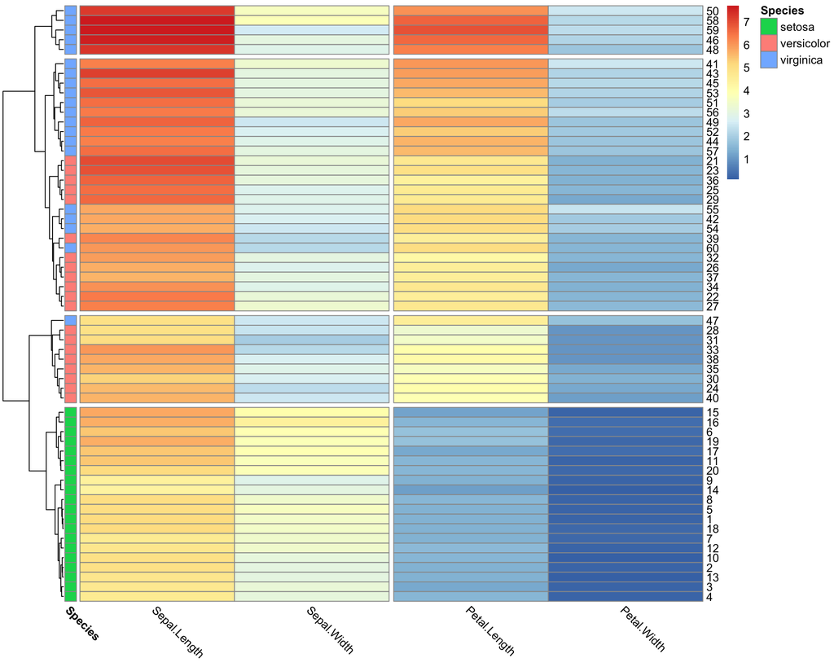

**Which answer is correct:**

A.) `annotation_row = annotation_df`  
B.) `cluster_cols = F`  
C.) `gaps_col = 2`  
D.) `cluster_rows = F`

## Question 15: Merging tables - *Part1*

How many rows and columns will the resulting dataframe have after merging the two dataframes **df1** and **df2** using the following code:

`left_join(df1, df2, by = "ID")`

**df1:**

```
##   Sepal.Length Sepal.Width   Species ID
## 1          4.3         3.0    setosa  1
## 2          5.0         3.3    setosa  2
## 3          7.7         3.8 virginica  3
```

**df2:**

```
##   Petal.Length Petal.Width   Species ID
## 1          1.1         0.1    setosa  2
## 2          1.4         0.2    setosa  3
## 3          6.7         2.2 virginica  4
```

**Which answer is correct:**

A.) Columns: `4`; Rows: `3`  
B.) Columns: `4`; Rows: `6`  
C.) Columns: `7`; Rows: `3`  
D.) Columns: `8`; Rows: `3`

## Question 16: Merging tables - *Part2*

If you execute the code: `left_join(df1, df2, by = "ID")` on the dataframes **df1** and **df2** as described in the question before, how many *NA* values will the resulting table have in total?

**Which answer is correct:**

A.) `0`  
B.) `1`  
C.) `2`  
D.) `3`

## Question 17: Modeling - *Part1*

Which line of code will resolve the following error that results when executing the command `cor(iris)`?

```
## Error in cor(iris): 'x' must be numeric
```

**Which answer is correct:**

A.) `iris %>% filter(Sepal.Width >= 3) %>% cor()`  
B.) `iris %>% select(-Species) %>% cor()`  
C.) `iris %>% mutate(width_sum = Sepal.Width + Petal.Width) %>% cor()`  
D.) `iris %>% select(-Sepal.Length) %>% cor()`

## Question 18: Modeling - *Part2*

What kind of model is used here and which variable is the dependent variable?

```
##
## Call:
## lm(formula = Petal.Length ~ Petal.Width, data = iris)
##
## Coefficients:
## (Intercept)  Petal.Width
##       1.084        2.230
```

**Which answer is correct:**

A.) logistic model; *Petal.Length* is the dependent variable  
B.) linear model; *Petal.Width* is the dependent variable  
C.) linear model; *Petal.Length* is the dependent variable  
D.) logistic model; *Petal.Width* is the dependent variable